# IBRO

2023-05-21

# Single-cell RNA-seq data analysis using **Seurat**

In this section we will learn to:

1. Read count matrices
2. Data pre-processing
   - Perform quality control
   - Normalize data to log
   - Identification of highly variable features (gene selection)
3. Group data into cell types
   - Data scaling
   - Principal Component Analysis (PCA)
   - Clustering
   - UMAP visualization
4. Find differential expressed genes (cluster biomarkers)
5. Visualize expression data
   - Violin plot
   - Color UMAP by gene expression
   - Dot plot
6. Subsample data
7. Use TPM matrices in a Seurat object

### Load libraries

First, we load all the libraries we need. Libraries are packages of functions we can install but need to be loaded every time we restart R

```r
library(dplyr)
library(Seurat)
library(patchwork)
library(data.table)
library(ggplot2)
```

## Data pre-processing

### Load RGC data from Tran et al. 2019

Load counts and save them in R format

```r
# Load the RGC dataset
counts <- t(read.table('C:/Users/gisel/Documents/McGill/Summer2023/IBRO2023/Seurat/AdultRGCs/GSE133382_AtlasRGCs_CountMatrix.csv',sep = ',', header = TRUE, row.names = 1))

# Save data set in R format to read faster next time
save.image("C:/Users/gisel/Documents/McGill/Summer2023/IBRO2023/Seurat/AdultRGCs/Atlascounts.RData")
```

```r
# Here only a subset of the data is selected so the tutorial can run faster in my laptop
# Keep 5000 genes plus genes of interest
# Keep the first 10000 cells
genes2keep <- c(setdiff( which(colnames(counts) %in% c("Rbfox3", "Gfap", "Rbpms", "Slc17a6", "Slc32a1","Vsx2","Arr3","Slc1a3","Cdh1",  "Cdh2",  "Cdh3",  "Cdh4" , "Cdh6",  "Cdh7",  "Cdh8",  "Cdh9",  "Cdh10", "Cdh11", "Cdh12", "Cdh13", "Cdh15", "Cdh18", "Cdh20","Cdh22", "Cdh23", "Cdh24" )), 1:5000), c(1:5000))
counts <- counts [1:10000, genes2keep]
save.image("W:/IBRO2023/Seurat/AdultRGCs/Atlascounts_subset.RData")
```

Load counts and convert it in Seurat format.  
The input matrix must have genes in the rows, cells in the columns.

```r
# Load data set in R format
# load("F:/Documents/AjunrGrant2021/RGC/Atlascounts.RData") # full version
load("W:/IBRO2023/Seurat/AdultRGCs/Atlascounts_subset.RData")
# Initialize the Seurat object with raw counts(non-normalized data).
# unnormalized data with cells as columns and features (genes) as rows

CountsAtlas <- CreateSeuratObject(counts = t(counts), project = "RGCAtlas")
CountsAtlas
```

```
## An object of class Seurat
## 5020 features across 10000 samples within 1 assay
## Active assay: RNA (5020 features, 0 variable features)
```

Take a look at the data for a few genes and 10 cells

```r
t(counts[1:10, c("Cdh4", "Cdh13", "Cdh7")])
```

```
##       aRGC1_AAACCTGAGAATCTCC.1 aRGC1_AAACCTGAGCGACGTA.1
## Cdh4                         1                        0
## Cdh13                        0                        0
## Cdh7                         0                        1
##       aRGC1_AAACCTGGTAAATGAC.1 aRGC1_AAACCTGGTACAGTTC.1
## Cdh4                         0                        1
## Cdh13                        0                        0
## Cdh7                         2                        0
##       aRGC1_AAACCTGTCAAGGCTT.1 aRGC1_AAACGGGAGCAGCGTA.1
## Cdh4                         0                        0
## Cdh13                        0                        4
## Cdh7                         1                        0
##       aRGC1_AAACGGGAGCCAACAG.1 aRGC1_AAACGGGCAATCTACG.1
## Cdh4                         0                        3
## Cdh13                        0                        3
## Cdh7                         0                        0
##       aRGC1_AAACGGGCACCACCAG.1 aRGC1_AAACGGGCACCGATAT.1
## Cdh4                         0                        0
## Cdh13                        0                        1
## Cdh7                         0                        0
```

```r
rm(counts)
```

To load 10x Data: Directory containing the matrix.mtx, genes.tsv (or features.tsv), and barcodes.tsv files provided by 10X

```r
counts <- Read10X(data.dir = "DataDirectory") # replace "DataDirectory" with your own path
```

#### set seed so our result are reproducible

```r
set.seed(0)
```

### Perform quality control

Visualize QC metrics as a violin plot

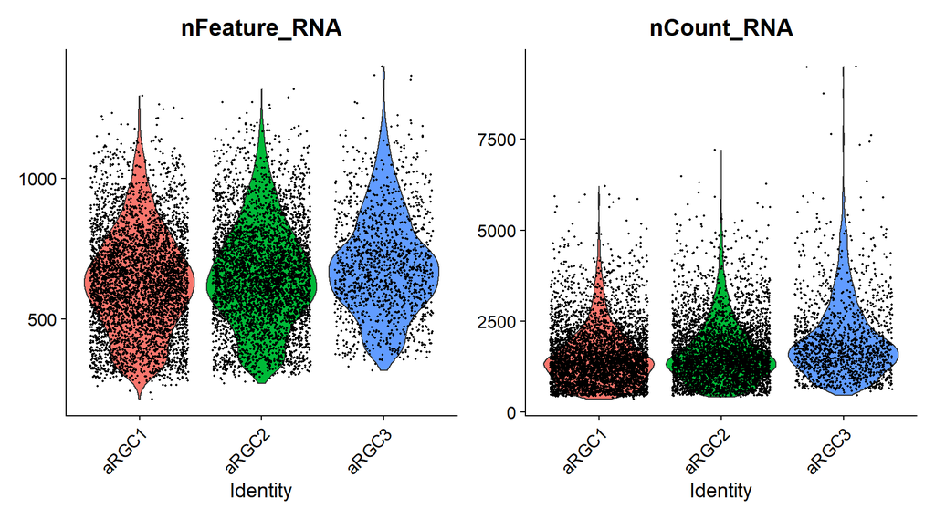

```r
QCviolin <- VlnPlot(object = CountsAtlas, features = c("nFeature_RNA", "nCount_RNA"), ncol = 2)
QCviolin
```

*FeatureScatter* is typically used to visualize feature-feature relationships

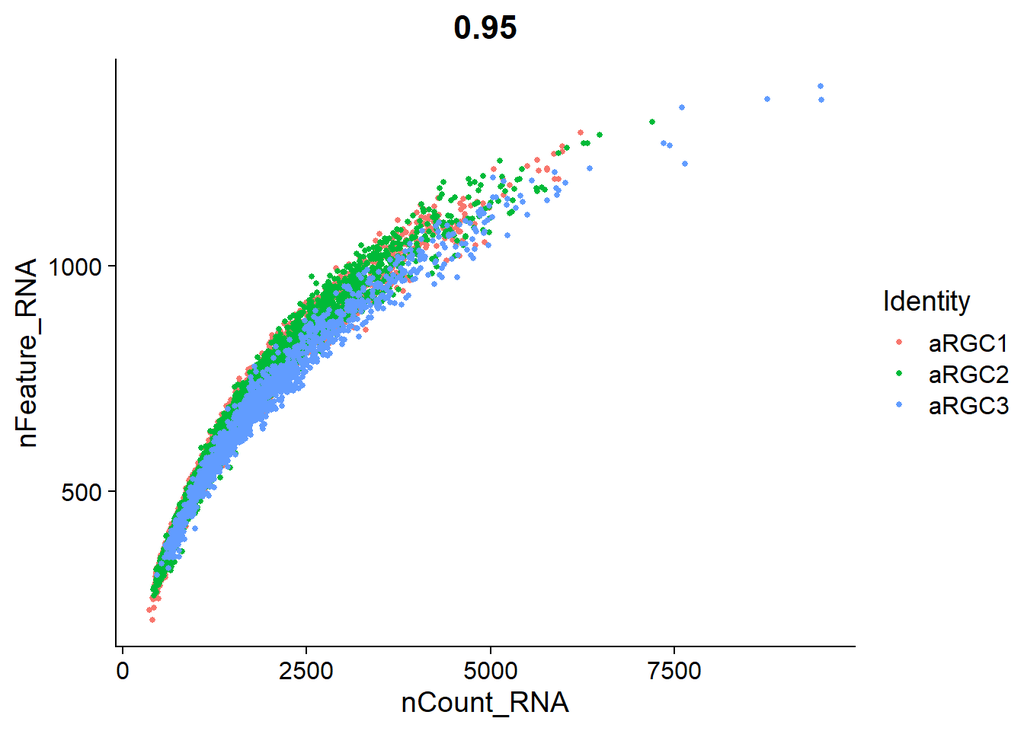

```r
plot2 <- FeatureScatter(object = CountsAtlas, feature1 = "nCount_RNA", feature2 = "nFeature_RNA")
plot2
```

```r
# CountsAtlas <- subset(x= CountsAtlas, subset = nFeature_RNA > 2000 & nFeature_RNA < 7500)
CountsAtlas <- subset(CountsAtlas, subset = nFeature_RNA > 200 & nFeature_RNA < 1100)
```

### Normalize data

Normalize the gene expression measurements for each cell by the total expression

```r
CountsAtlas <- NormalizeData(object = CountsAtlas, normalization.method = "LogNormalize", scale.factor = 10000)
```

## Identification of highly variable features (gene selection)

```r
CountsAtlas <- FindVariableFeatures(object = CountsAtlas, selection.method = "vst", nfeatures =2000)

# Identify the 10 most highly variable genes
top10 <- head(VariableFeatures(object = CountsAtlas), 10)

# plot variable features with labels
plot1 <- VariableFeaturePlot(CountsAtlas)
plot2 <- LabelPoints(plot = plot1, points = top10, repel = TRUE)
```

```
## When using repel, set xnudge and ynudge to 0 for optimal results
```

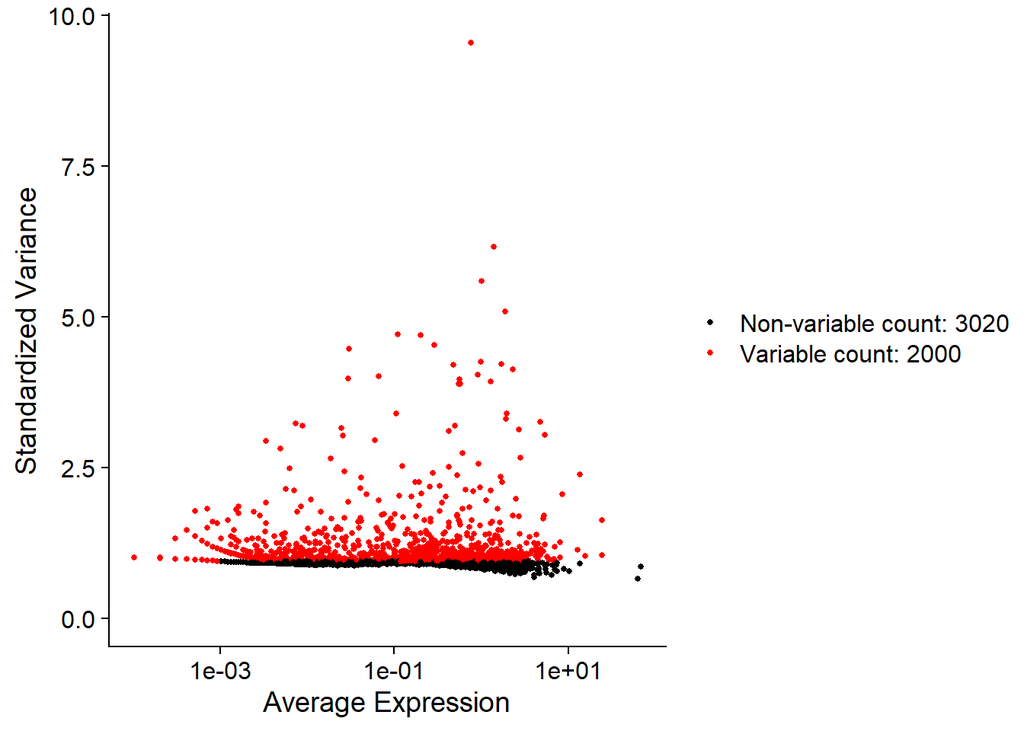

```r
plot1
```

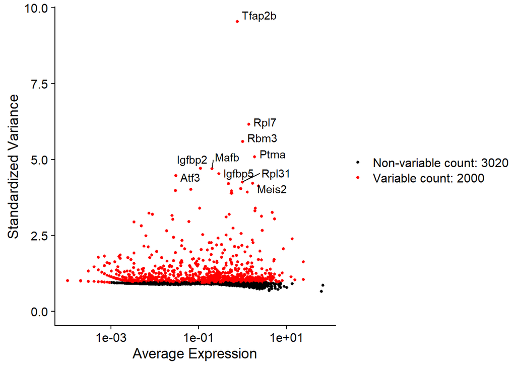

```r
plot2
```

## Grouping “cell types” in dataset

### Scaling data:

Scaling is a necessary standard pre-processing for downstream analysis that use dimensional reduction techniques like principal component analysis (PCA).

This step is important because allows us to consider genes with a lot and few counts equally, while focusing more in their variability. In this way, highly-expressed genes do not dominate. For this, *ScaleData*:

- Shifts the expression of each gene, so that the mean expression across cells is 0,
- Scales the expression of each gene, so that the variance across cells is 1.

```r
#For all genes
all.genes <- rownames(CountsAtlas)
CountsAtlas <- ScaleData(object = CountsAtlas, features = all.genes) #takes < 10min to run if using all counts and genes
```

If *features* is not specified, only the top 2000 genes are used. In this example only 2000 (default) will be use for clustering given the computer power available but results usually remain pretty similar to those of “all.genes”.

```r
CountsAtlas <- ScaleData(object = CountsAtlas) #takes ~10min to run
```

### Linear dimension reduction

The amount of data we have is huge **(42750 cells and 27933 genes!!!)** if using the whole dataset. So we need to make it smaller but at the same time conserve the important information. For this we can use PCA, which is a mathematical method that takes huge amounts of data and keeps only the information that accounts for the majority of the variability in the data.

```r
# Here we use the previously 2000 variable genes we selected above
CountsAtlas <- RunPCA(object = CountsAtlas, features =  VariableFeatures(object = CountsAtlas), npcs = 100) # take a few minutes to run
```

```
## PC_ 1
## Positive:  Nnat, Serpine2, Tshz2, Lypd1, Fgf13, Bex1, Khdrbs2, Cnih3, Myo1b, Tenm1
##     Scg2, Xist, Pde1a, C1ql2, Slc24a5, Brinp3, 2600014E21Rik, Cdh13, Bex4, 6330403A02Rik
##     Gad1, Mstn, Slc32a1, A830018L16Rik, H3f3a, Gpr101, Lhx9, Tfap2b, Thsd7b, Asic4
## Negative:  Syt2, Atp1b1, Uhmk1, Dst, Slc17a6, Dnm1, Cds2, Lpgat1, Mfsd6, Syp
##     Nckap1, Kcnq2, Ttbk2, Stxbp1, Ogfrl1, Olfm1, Enah, Snph, Map1a, Adam23
##     Map2, Camk1d, Slc6a8, Unc80, Disp2, Dzank1, Cab39, Nmnat2, Fam168b, Sphkap
## PC_ 2
## Positive:  Xist, Slc12a5, Dst, Cdc42bpa, Kcnb1, Cds2, Unc80, Ttbk2, Map2, Scn1a
##     Disp2, Map1a, Fam126b, Sphkap, Dzank1, Enah, 5330434G04Rik, Spred1, B3galt2, Agap1
##     Adam23, Inpp4a, Pbx1, Nav1, Lonrf2, Prrc2b, Kifap3, Gls, Slc4a3, Syt2
## Negative:  Rbm3, Rpl36a, Rpl12, Rpl7, Rpl31, Pin4, Ptma, Rpl7a, Dstn, Rps4x
##     Hnrnpa3, Hnrnph2, Oser1, Cxx1a, Serf2, Gm6710, Cir1, Tubb4b, Ndufs3, Emc4
##     Gnas, Tmem163, Nop56, Gm14296, Rpl39, Map1lc3a, Gm15013, Tmx2, Nono, H3f3a
## PC_ 3
## Positive:  Stmn3, Scn1a, Slc17a6, Map1a, Mgst3, Adora1, Myo1b, Kifap3, Mfsd6, Resp18
##     Rbpms, Tuba4a, Ano3, Bend6, Olfm1, Nacc2, Scg5, Rgs4, Napb, Tshz2
##     Atp1b1, Degs1, Tanc1, Atp6ap2, Lypd6, Plcb1, Kcnh7, Ctsz, Ckmt1, Tmeff2
## Negative:  Gad1, C1ql2, Slc32a1, Tfap2b, Frmd5, Gad2, Meis2, Lhx9, Igfbp2, Ucma
##     Tfap2c, Asic4, Fibcd1, Zeb2, Dach2, Rasgrp1, Steap3, Unc80, Pax6, G630016G05Rik
##     Gabra3, Pmepa1, Bex1, Rgs8, Cdk18, Nr4a2, Slitrk2, Pcdh19, Kcnip3, Hsd17b12
## PC_ 4
## Positive:  Psma7, Myo1b, Atp5e, Bex1, Atp5c1, Rps21, Myeov2, Ndufa1, Khdrbs2, Tshz2
##     Gdi1, Fgf13, Xist, Psmd14, Romo1, Raly, Idh3b, Nnat, Scg2, Eif3m
##     Mrpl15, Dbi, Hprt, Cox7b, Tenm1, Ndufa10, Phyh, Pax6, C1qtnf4, Maged2
## Negative:  Pam, Rbm3, Rpl36a, Rpl12, Rpl7, Pin4, Atp1b1, Rpl31, Syt2, Rpl7a
##     Tmem163, Sphkap, Dnm1, Atp2b4, Oser1, Gm6710, Dstn, Gm14296, Ptma, Hs6st2
##     Ptp4a1, Usp9x, Pcdh11x, Gm13889, Etl4, Cir1, Set, Hnrnph2, Gnas, Serf2
## PC_ 5
## Positive:  Atp2b4, Sphkap, Prkcq, Pcdh19, Etl4, Pcdh11x, Rprm, Lrrc4c, Rgs4, Slc25a5
##     Hs6st2, Gabra3, Atp5g3, Dmd, Chrna4, Tagln2, Cdh8, Atp5c1, Ramp1, Kcnb2
##     Phyh, Rasgrp1, Creg2, Zcchc12, Cox7b, Idh3b, Syt13, Igfbp5, Lrp1b, Atp1b1
## Negative:  Gria3, Ogfrl1, Ano3, Mmp9, Myo1b, Tnr, Rgs8, Tanc1, Pkp4, Lypd1
##     Cdh4, Adora1, Slc24a3, B3gat2, Raly, Tshz2, Scn1a, Tmem163, Ppp1r1c, Nacc2
##     Mafb, Ttn, D430041D05Rik, Slc12a5, Zfp385b, Fam217b, Pax6, Itpka, Tmem35, Slc32a1
```

#### Determine the ‘dimensionality’ of the dataset

PCA will return a matrix of the same dimension as input matrix. However, this PCA matrix contains *“eigenvalues”* which represent the weight of each gene in each PC (eigenvector). PCA accumulates the major information variability in the top PCs and almost none in the bottom ones. Therefore, we want to only select a few of the top PCs that more robustly represent a compression of our dataset. **But exactly how many?**

Selecting the right amount of PCs is challenging and a little arbitrary.You could try using many methods found in the Seurat website, but for now here is an heuristic method that gives a good approximate without using a lot of computational power.

Here, we plot the standard deviation of the PCs to identify the “elbow”, which corresponds with the significant dimension in the PC that contains the relevant information of our data.

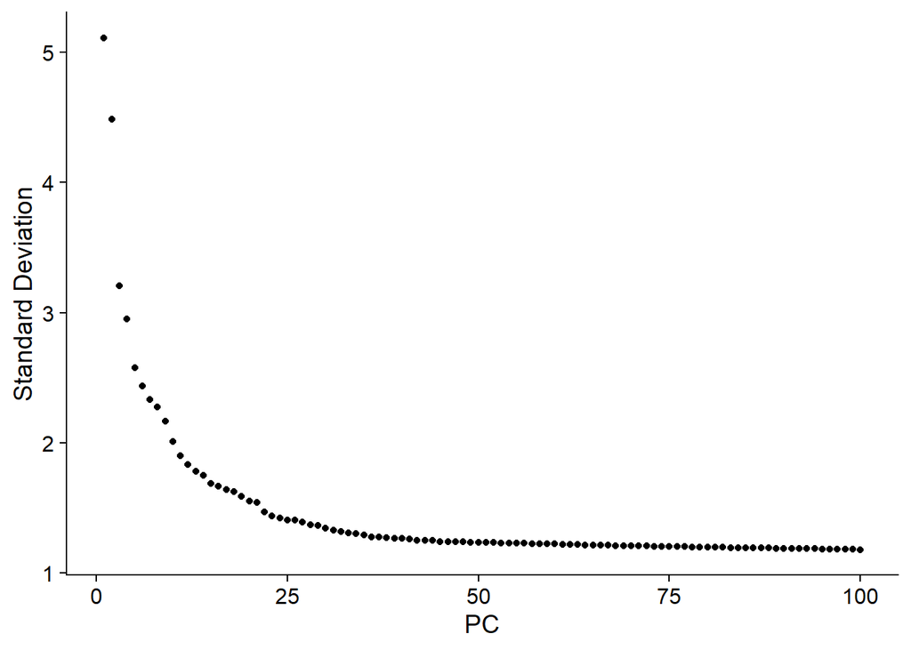

```r
# Here we select only the first 100 PCs to be displayed
ElbowPlot(object = CountsAtlas, ndims = 100)
```

Once we selected our PCs, we can go ahead and use them to cluster cells into different groups based on expression.

Although the math behind the clustering methods is complex, we just need to understand that based on how similar cells are they are pulled together while dissimilarities push them away.

*FindNeighbors* finds the distance between cells while *FindClusters* groups cells based on these distances.

### Clustering

In this first clustering I want to identified if in the dataset I have cell types other than RGC so I use a low resolution. Values > 1 are high resolution and <1 are low resolution, but it needs to be setup based on the data we are looking at.

```r
CountsAtlas <- FindNeighbors(object = CountsAtlas, dims = 1:60) # 60 PCs are used
CountsAtlas <- FindClusters(object = CountsAtlas, resolution = 0.2)
```

```
## Modularity Optimizer version 1.3.0 by Ludo Waltman and Nees Jan van Eck
##
## Number of nodes: 9872
## Number of edges: 451751
##
## Running Louvain algorithm...
## Maximum modularity in 10 random starts: 0.9506
## Number of communities: 15
## Elapsed time: 1 seconds
```

#### Run non-linear dimensional reduction (UMAP)

After we have our clusters we can use a visualization method to explore our datasets in a 2-D space.

Here is recommended to use the same numbers of PCs we used for our clustering

```r
CountsAtlas <- RunUMAP(object = CountsAtlas, dims = 1:60)
```

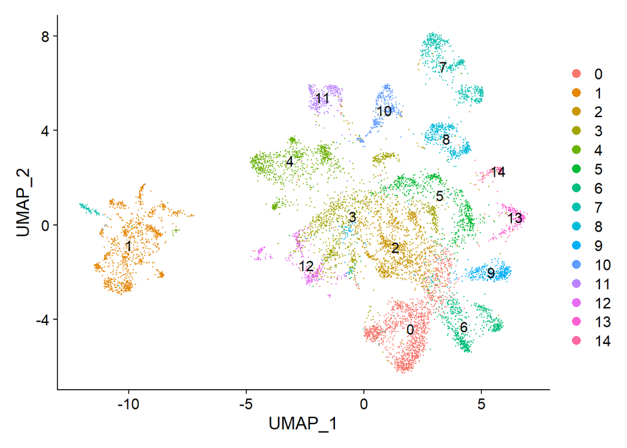

```r
UMAPplot <- DimPlot(object = CountsAtlas, reduction = "umap",  label = TRUE)
UMAPplot
```

Once we are done with this part of the analysis you can save this pre-processed data in R format so you don’t have to run it again.

```r
save.image("W:/IBRO2023/PreprocessedDataRGCs.RData")
```

Or only save the Seurat object

```r
saveRDS(object = CountsAtlas, file = "W:/IBRO2023/CountsAtlasW:/IBRO2023/CountsAtlas.rds")
```

To reload your data you can simply read the file you saved (image or object). **Note that libraries need to be re-load if you closed R**

```r
load("W:/IBRO2023/PreprocessedDataRGCs.RData")
#readRDS("W:/IBRO2023/CountsAtlas.rds")
```

## Finding differentially expressed features (cluster biomarkers)

Seurat can help us identified markers that define our cluster based on differential expression. For this, we can use positive and negative markers.

Let’s start with finding markers in cluster 1 and look at the top 5 markers

*ident.1* defines the cluster you want to find marker for

```r
cluster2.markers <- FindMarkers(CountsAtlas, ident.1 = 1, min.pct = 0.25) # ~9 min to run
```

[output not shown]

```r
head(cluster2.markers, n = 5) # top 5 markers
```

```
##         p_val avg_log2FC pct.1 pct.2 p_val_adj
## Rpl7        0   4.173428 0.982 0.161         0
## Rpl31       0   3.609400 0.974 0.177         0
## Ptma        0   3.501730 0.999 0.376         0
## Tmem163     0   2.223795 0.984 0.550         0
## Tubb4b      0   1.427885 0.975 0.705         0
```

We can also compare one cluster vs any other numbers of clusters. For example cluster 4 vs cluster 1 and 3

```r
cluster4.markers <- FindMarkers(object = CountsAtlas, ident.1 = 4, ident.2 = c(1, 3), min.pct = 0.25)
head(cluster4.markers, n = 5)
```

```
##                p_val avg_log2FC pct.1 pct.2     p_val_adj
## Atp2b4 1.896518e-269   2.404887 0.891 0.305 9.520522e-266
## Rgs4   1.702627e-235   1.684924 0.994 0.852 8.547189e-232
## Etl4   6.655747e-179   2.032909 0.627 0.150 3.341185e-175
## Lrp1b  4.633421e-170   1.562902 0.922 0.652 2.325977e-166
## Sphkap 1.046062e-161   1.404171 0.953 0.729 5.251231e-158
```

To find positive makers for every cluster in which the log fold change is at least 2.

```r
CountsAtlas.markers <- FindAllMarkers(object = CountsAtlas, only.pos = TRUE, min.pct = 0.25, logfc.threshold = 2) # take ~15min to run
CountsAtlas.markers %>%
    group_by(cluster) %>%
    slice_max(n = 2, order_by = avg_log2FC)
```

To look into a subset of genes and see if this are DE we can give Seurat a list with these genes. Here I’m loading a list of genes from a text file containing Cadherin genes

```r
cdhs<-  read.table("F:/Documents/Drop-seq-Sanes/AjunGrant/Cdhs", stringsAsFactors = FALSE)$V1
markersCdhs <- FindAllMarkers(object =CountsAtlas, features = cdhs, only.pos= T,logfc.threshold = .2)
cdhs
```

```
##  [1] "Cdh1"  "Cdh2"  "Cdh3"  "Cdh4"  "Cdh6"  "Cdh7"  "Cdh8"  "Cdh9"  "Cdh10"
## [10] "Cdh11" "Cdh12" "Cdh13" "Cdh15" "Cdh18" "Cdh20" "Cdh22" "Cdh23" "Cdh24"
```

```r
markersCdhs
```

```
##                p_val avg_log2FC pct.1 pct.2     p_val_adj cluster  gene
## Cdh13   2.465859e-58  1.0461173 0.470 0.322  1.237861e-54       0 Cdh13
## Cdh10   3.785115e-13  0.6680556 0.186 0.127  1.900128e-09       0 Cdh10
## Cdh2    1.634968e-34  0.4431746 0.545 0.348  8.207538e-31       1  Cdh2
## Cdh131  1.452227e-13  0.2209838 0.455 0.328  7.290178e-10       1 Cdh13
## Cdh4    5.922522e-44  0.7722806 0.570 0.414  2.973106e-40       2  Cdh4
## Cdh8    1.832992e-31  0.8561888 0.196 0.092  9.201618e-28       2  Cdh8
## Cdh20   5.155795e-22  0.6208674 0.129 0.058  2.588209e-18       2 Cdh20
## Cdh101  1.362970e-03  0.3118762 0.161 0.132  1.000000e+00       2 Cdh10
## Cdh41   5.660591e-50  0.4812697 0.682 0.402  2.841617e-46       3  Cdh4
## Cdh7    1.227047e-40  0.4993144 0.359 0.177  6.159774e-37       3  Cdh7
## Cdh21   2.568323e-16  0.4637680 0.491 0.362  1.289298e-12       4  Cdh2
## Cdh12   1.452277e-08  0.3865728 0.187 0.121  7.290430e-05       4 Cdh12
## Cdh201  1.160930e-57  0.8215422 0.216 0.056  5.827868e-54       5 Cdh20
## Cdh11   5.081341e-15  0.3962160 0.279 0.157  2.550833e-11       5 Cdh11
## Cdh81   2.913067e-14  0.3448582 0.197 0.099  1.462360e-10       5  Cdh8
## Cdh132  4.188208e-58  0.9329219 0.611 0.325  2.102480e-54       6 Cdh13
## Cdh1   4.311130e-171  0.8949180 0.133 0.005 2.164187e-167       7  Cdh1
## Cdh71   1.335280e-66  0.6426294 0.484 0.176  6.703107e-63       7  Cdh7
## Cdh121  9.559238e-65  0.6512693 0.355 0.110  4.798738e-61       7 Cdh12
## Cdh22   2.192462e-20  0.3235980 0.138 0.049  1.100616e-16       7 Cdh22
## Cdh111 1.818865e-125  1.6820417 0.568 0.147 9.130703e-122       8 Cdh11
## Cdh122  8.047718e-58  1.4433514 0.365 0.116  4.039954e-54       8 Cdh12
## Cdh72   7.189388e-15  0.5253955 0.350 0.190  3.609073e-11       8  Cdh7
## Cdh18   1.619210e-13  0.5695609 0.221 0.107  8.128433e-10       8 Cdh18
## Cdh42   1.768806e-15  0.6543334 0.578 0.427  8.879404e-12       9  Cdh4
## Cdh123  7.454357e-03  0.3481028 0.163 0.125  1.000000e+00       9 Cdh12
## Cdh43   1.915292e-46  1.0399255 0.763 0.421  9.614765e-43      10  Cdh4
## Cdh124  9.100994e-13  0.5675301 0.251 0.122  4.568699e-09      10 Cdh12
## Cdh73  6.818378e-132  1.6840607 0.708 0.179 3.422826e-128      11  Cdh7
## Cdh82  1.092249e-113  1.5350029 0.483 0.092 5.483089e-110      11  Cdh8
## Cdh221  4.078630e-48  1.1136824 0.234 0.049  2.047472e-44      11 Cdh22
## Cdh181  1.571888e-19  0.6838597 0.267 0.106  7.890877e-16      11 Cdh18
## Cdh112  9.504714e-07  0.3034392 0.274 0.161  4.771367e-03      11 Cdh11
## Cdh202  3.674827e-04  0.3118150 0.116 0.065  1.000000e+00      11 Cdh20
## Cdh74  9.596683e-178  2.5002761 0.877 0.181 4.817535e-174      13  Cdh7
## Cdh44   4.434638e-72  1.5206237 0.899 0.422  2.226188e-68      13  Cdh4
## Cdh113  7.224215e-12  0.6284243 0.335 0.161  3.626556e-08      13 Cdh11
## Cdh9   1.336112e-131  0.9936921 0.171 0.003 6.707282e-128      14  Cdh9
## Cdh125  9.833741e-30  1.2039150 0.495 0.122  4.936538e-26      14 Cdh12
## Cdh102  9.977138e-16  0.9775231 0.410 0.133  5.008523e-12      14 Cdh10
## Cdh15   1.014149e-03  0.4101910 0.181 0.088  1.000000e+00      14 Cdh15
```

### Visualizing data

#### Look at specific genes across clusters

**Violin plot** Here we can compare the distribution of markers across cells in each cluster.  
We can find neurons using *Rbfox3* gene and glia using *Gfap* gene. This data doesn’t contain glia cells.

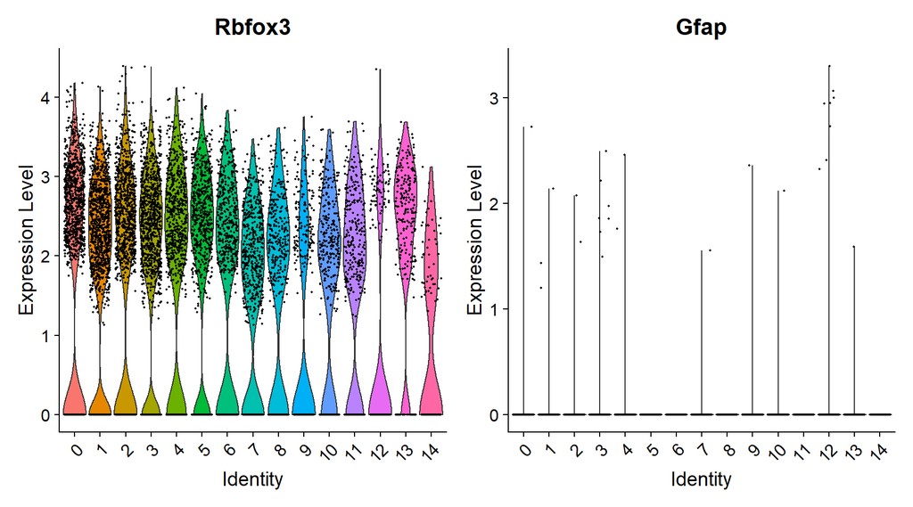

```r
VlnPlot(object = CountsAtlas, features = c("Rbfox3", "Gfap"))
```

**UMAP**  
Another way to look at the whole data while looking at genes expression is by coloring our UMAP based on genes expression.

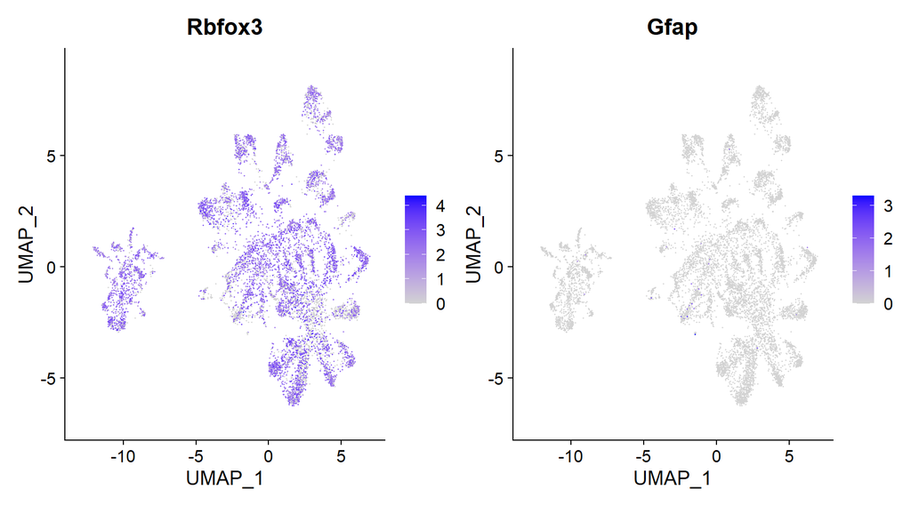

```r
FeaturePlot(object = CountsAtlas, features = c("Rbfox3", "Gfap"))
```

We can also look at both features at the same time

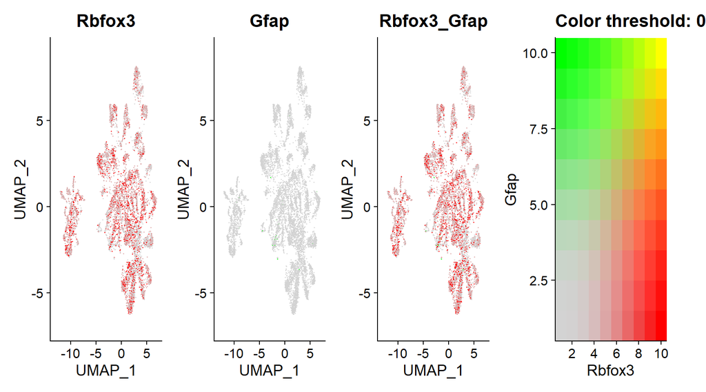

```r
FeaturePlot(CountsAtlas, features = c("Rbfox3", "Gfap"), blend = TRUE)
```

#### Search for cell types

Here, we take a look at RGC (Rbpms, Slc17a6), amacrine (Slc32a1), bipolar(Vsx2) and photoreceptor (Arr3) cell markers. We only have RGCs and ACs in this dataset.

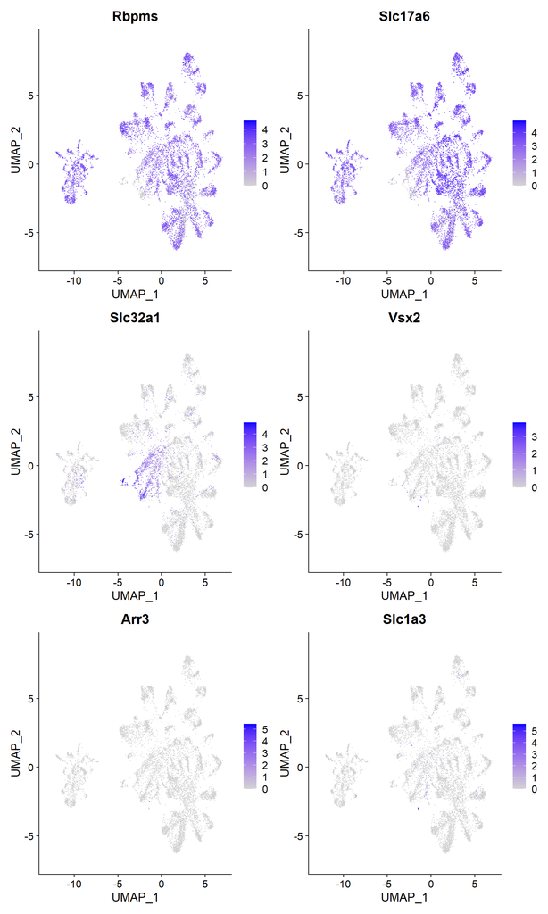

```r
celltypeMarkers <- c("Rbpms", "Slc17a6", "Slc32a1","Vsx2","Arr3","Slc1a3") #Save genes names in a variable
FeaturePlot(object = CountsAtlas, features = celltypeMarkers)
```

**DotPlot**

*DotPlot* to look at the expression of many genes and the amount of cells following that expression pattern inside the cluster.

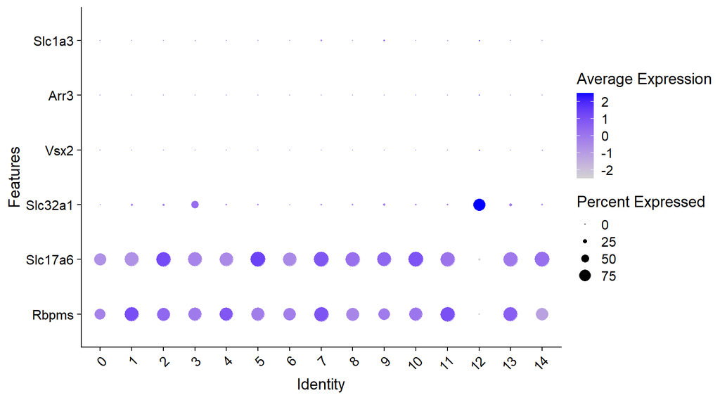

```r
DotPlot(object = CountsAtlas, features = celltypeMarkers) + RotatedAxis() + coord_flip()
```

**Gene average expression per cluster**  
We can also calculate the average expression for our genes of interest

```r
AverageExpMarkers <- AverageExpression(object = CountsAtlas, features = celltypeMarkers)
AverageExpMarkers
```

```
## $RNA
##                   0           1           2           3            4
## Rbpms   13.51486922 20.30685832 16.98684431 14.48929234 19.182218771
## Slc17a6 19.93817154 19.92028919 37.65662347 23.03624188 21.762218530
## Slc32a1  0.32178998  0.80987113  0.84368689  5.36719037  0.645186187
## Vsx2     0.04536624  0.01225424  0.02310103  0.04289648  0.035627832
## Arr3     0.01020533  0.00000000  0.00000000  0.00279180  0.007275849
## Slc1a3   0.04789443  0.07344770  0.03938787  0.20355877  0.230702840
##                   5            6            7           8          9
## Rbpms   14.05462867 13.969347860 19.586495214 12.87643532 14.3170741
## Slc17a6 39.42969661 21.711743440 34.737604819 28.14047909 30.9279131
## Slc32a1  0.29905622  0.363182558  0.496430299  0.53883168  1.6776225
## Vsx2     0.01758196  0.006606874  0.004117195  0.00000000  0.0000000
## Arr3     0.00000000  0.000000000  0.000000000  0.00000000  0.0000000
## Slc1a3   0.05153474  0.021350390  0.259300664  0.03250183  0.7069404
##                  10          11         12          13         14
## Rbpms   15.00211787 20.11765573  1.1597371 18.09046222  9.1576457
## Slc17a6 35.48456106 27.19106069  1.8272052 25.86929173 28.6214102
## Slc32a1  0.64234780  0.44956133 32.5198830  1.31493079  0.5256119
## Vsx2     0.02792732  0.05979000  0.8930800  0.01570512  0.0790973
## Arr3     0.04697317  0.02080434  0.7106752  0.00000000  0.0000000
## Slc1a3   0.07199608  0.07746586  3.1741436  0.09605949  0.0000000
```

Once we found the clusters that contain the cells we don’t want (in this case ACs), we subset our dataset and keep only the clusters we are interested on (RGCs). This remove cluster 3,20 and 29 because expression is > 1 if using the whole dataset.

```r
cells_to_remove <- WhichCells(object = CountsAtlas, idents = which(AverageExpMarkers$RNA["Slc32a1",] > 1)-1)
CountsAtlas_RGCs <- subset(CountsAtlas, cells = setdiff(Cells(CountsAtlas), cells_to_remove))

dim(CountsAtlas)
```

```
## [1] 5020 9872
```

```r
dim(CountsAtlas_RGCs)
```

```
## [1] 5020 7859
```

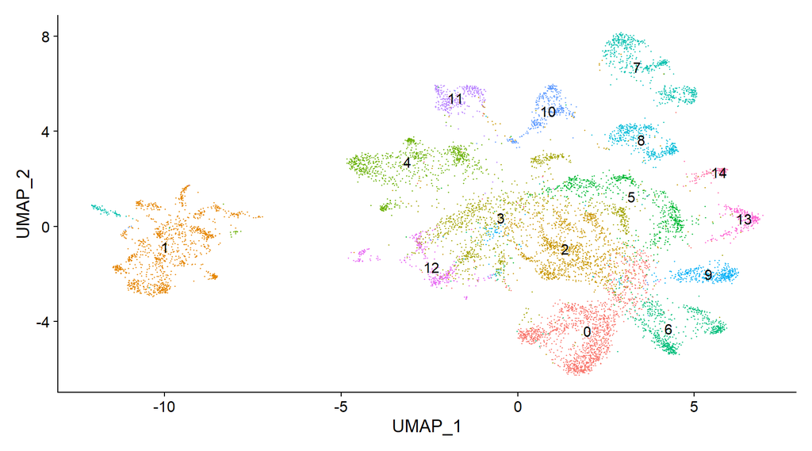

```r
UMAPplot + theme(legend.position = "none")
```

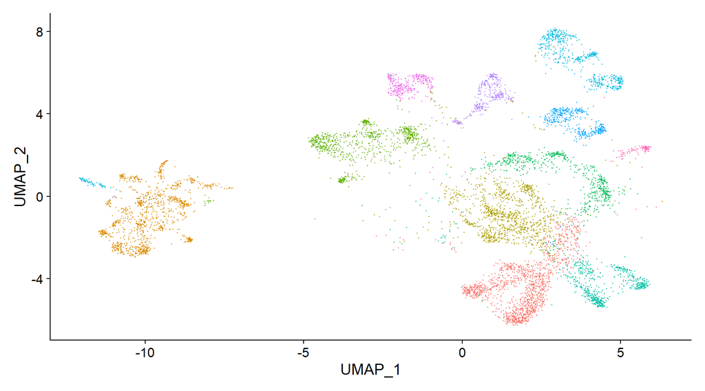

```r
DimPlot(object = CountsAtlas_RGCs, reduction = "umap") + theme(legend.position = "none")
```

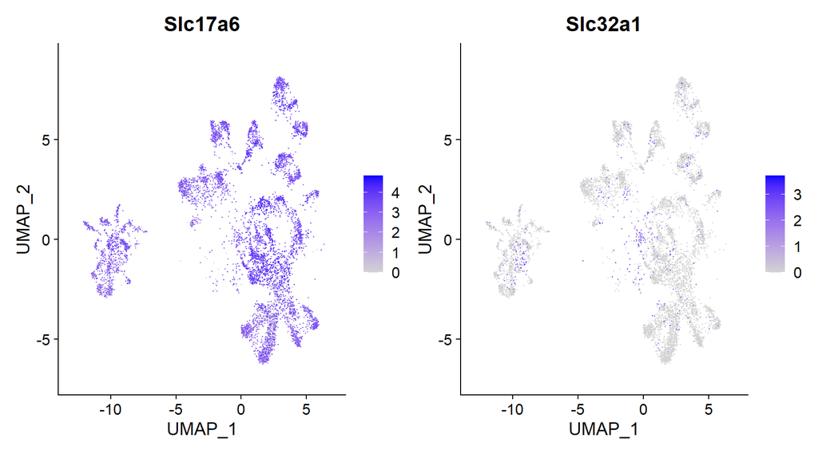

```r
FeaturePlot(object = CountsAtlas_RGCs, features = c("Slc17a6", "Slc32a1"))
```

Now we can re-cluster our data and look for RGC cells types if we wanted to. But given the resolution we stated in our clustering and that we did not remove many clusters we can keep using the same analysis we already have.

```r
CountsAtlas_RGCs <- FindVariableFeatures(object = CountsAtlas_RGCs, selection.method = "vst", nfeatures =2000)
CountsAtlas_RGCs <- ScaleData(object = CountsAtlas_RGCs) #takes ~10min to run
ElbowPlot(object = CountsAtlas_RGCs, ndims = 100)
CountsAtlas_RGCs <- FindNeighbors(object = CountsAtlas_RGCs, dims = 1:60) # 60 PCs are used
CountsAtlas_RGCs <- RunUMAP(object = CountsAtlas_RGCs, dims = 1:60)
DimPlot(object = CountsAtlas_RGCs, reduction = "umap")
```

Save data again

```r
save.image("W:/IBRO2023/PreprocessedDataRGCs_2.RData")
```

# TPM matrices

When downloading databases, sometimes we can also obtain data normalized by transcript per million (TPM). This data does not allow direct differential analysis (DE) like raw counts but it is good to visualize data and get a sense of the gene expression in our data set. In this example, we will use the same data than above (Tran et al., 2019) but download from the Broad Institute which comes as TPMs.

Load TPMs  
In this case the format of our data is a R file. You can load the data by simply using the *load* function. This file contains:

- *ExpMat*: a matrix with genes in rows and cells in column.
- *cell_types*: a factor vector with the the classification for each cell.

```r
rm() # remove all variables from directory
gc() # free unused memory
```

```
##             used  (Mb) gc trigger   (Mb)  max used   (Mb)
## Ncells   3078116 164.4    4556318  243.4   4556318  243.4
## Vcells 122057295 931.3  225432687 1720.0 225432657 1720.0
```

```r
load("F:/Documents/Drop-seq-Sanes/Tran_RGC_atlas_data.Rdata")
TPM_Atlas <- CreateSeuratObject(counts = ExpMat, project = "RGCAtlas") #Load TPM to a Seurat object
ExpMat[1:10, 1:10]
```

```
## 10 x 10 Matrix of class "dgeMatrix"
##         aRGC1_AAACCTGAGAATCTCC-1 aRGC1_AAACCTGAGCGACGTA-1
## Xkr4                   0.0000000                 0.000000
## Mrpl15                 0.0000000                 0.000000
## Lypla1                 0.6593396                 0.000000
## Gm37988                0.0000000                 0.000000
## Tcea1                  1.3351445                 0.000000
## Rgs20                  0.0000000                 0.000000
## Gm16041                0.0000000                 0.000000
## Atp6v1h                0.6593396                 1.684278
## Oprk1                  0.0000000                 0.000000
## Rb1cc1                 0.6593396                 0.000000
##         aRGC1_AAACCTGGTAAATGAC-1 aRGC1_AAACCTGTCAAGGCTT-1
## Xkr4                           0                0.8755425
## Mrpl15                         0                0.5306803
## Lypla1                         0                0.0000000
## Gm37988                        0                0.0000000
## Tcea1                          0                0.0000000
## Rgs20                          0                0.0000000
## Gm16041                        0                0.0000000
## Atp6v1h                        0                1.1314878
## Oprk1                          0                0.0000000
## Rb1cc1                         0                0.8755425
##         aRGC1_AAACGGGAGCAGCGTA-1 aRGC1_AAACGGGCAATCTACG-1
## Xkr4                   0.0000000                0.0000000
## Mrpl15                 0.7056362                0.6669501
## Lypla1                 0.4138084                0.3880769
## Gm37988                0.0000000                0.0000000
## Tcea1                  0.4138084                0.3880769
## Rgs20                  0.4138084                0.0000000
## Gm16041                0.0000000                0.0000000
## Atp6v1h                0.9312589                1.0635281
## Oprk1                  0.0000000                0.0000000
## Rb1cc1                 1.1152299                0.3880769
##         aRGC1_AAACGGGCACCACCAG-1 aRGC1_AAACGGGCAGCGTTCG-1
## Xkr4                   0.0000000                0.0000000
## Mrpl15                 0.7379037                0.8226186
## Lypla1                 0.0000000                1.2677659
## Gm37988                0.0000000                0.0000000
## Tcea1                  0.0000000                0.0000000
## Rgs20                  0.0000000                0.0000000
## Gm16041                0.0000000                0.0000000
## Atp6v1h                0.0000000                0.0000000
## Oprk1                  0.0000000                0.0000000
## Rb1cc1                 0.0000000                1.2677659
##         aRGC1_AAACGGGCAGGTTTCA-1 aRGC1_AAACGGGGTGTGAATA-1
## Xkr4                   0.0000000                0.0000000
## Mrpl15                 0.0000000                0.8790943
## Lypla1                 0.5656552                0.0000000
## Gm37988                0.0000000                0.0000000
## Tcea1                  0.0000000                0.0000000
## Rgs20                  0.9247357                0.0000000
## Gm16041                0.0000000                0.0000000
## Atp6v1h                0.5656552                0.8790943
## Oprk1                  0.0000000                0.0000000
## Rb1cc1                 0.9247357                0.8790943
```

```r
cell_type[1:5]
```

```
## aRGC1_AAACCTGAGAATCTCC-1 aRGC1_AAACCTGAGCGACGTA-1 aRGC1_AAACCTGGTAAATGAC-1
##                  7_Novel                 40_M1dup                 40_M1dup
## aRGC1_AAACCTGTCAAGGCTT-1 aRGC1_AAACGGGAGCAGCGTA-1
##                 27_Novel                 19_Novel
## 45 Levels: 1_W3D1.1 2_W3D1.2 3_FminiON 4_FminiOFF 5_J-RGC 6_W3B ... 45_AlphaOFFT
```

```r
levels(cell_type)
```

```
##  [1] "1_W3D1.1"     "2_W3D1.2"     "3_FminiON"    "4_FminiOFF"   "5_J-RGC"
##  [6] "6_W3B"        "7_Novel"      "8_Novel"      "9_Tbr1_Novel" "10_Novel"
## [11] "11_Novel"     "12_ooDS_NT"   "13_Novel"     "14_ooDS_Cck"  "15_Novel"
## [16] "16_ooDS_DV"   "17_Tbr1_S1"   "18_Novel"     "19_Novel"     "20_Novel"
## [21] "21_Tbr1_S2"   "22_M5"        "23_W3D2"      "24_Novel"     "25_Novel"
## [26] "26_Novel"     "27_Novel"     "28_FmidiOFF"  "29_Novel"     "30_Novel"
## [31] "31_M2"        "32_F_Novel"   "33_M1"        "34_Novel"     "35_Novel"
## [36] "36_Novel"     "37_Novel"     "38_FmidiON"   "39_Novel"     "40_M1dup"
## [41] "41_AlphaONT"  "42_AlphaOFFS" "43_AlphaONS"  "44_Novel"     "45_AlphaOFFT"
```

Since the file already has the cell type for each cell, it is not necessary to create our own cluster and we can look at the interesting features of the gene of interest.

```r
# Add cell type to my Seurat object
Idents(object = TPM_Atlas) <- cell_type
```

Let’s say we want to take a look at the expression of a gene across all cell types. For example *Cdh4*

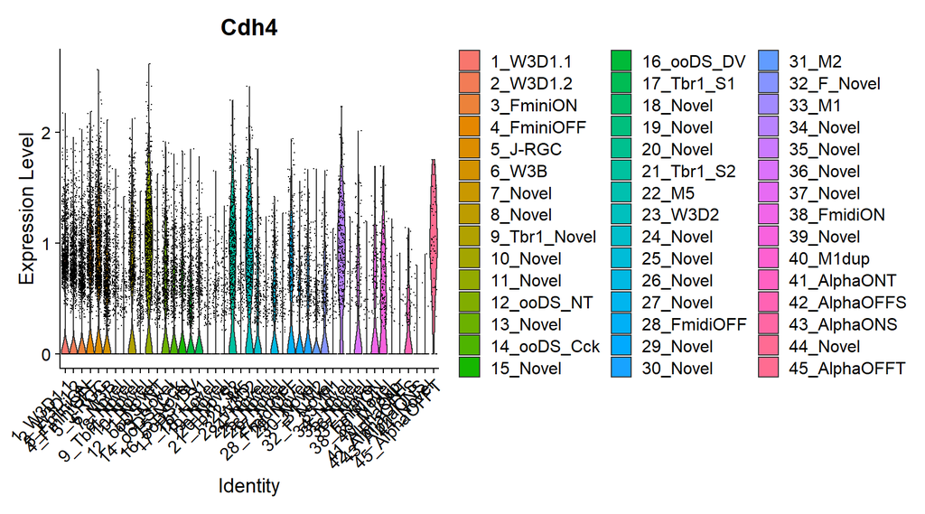

```r
VlnPlot(object = TPM_Atlas, features = c("Cdh4"))
```

We can customize the appearance of our plots

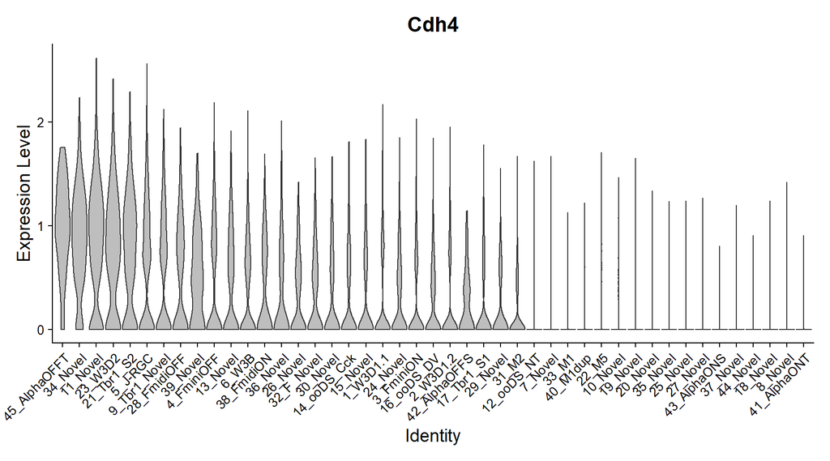

```r
VlnPlot(object = TPM_Atlas, features = c("Cdh4"), cols = rep("gray", length(levels(Idents(object = TPM_Atlas)))), sort = 'increasing', pt.size = 0 )  + theme(legend.position = "none", axis.text = element_text(size = 10))
```

Dot plots can be plotted too.

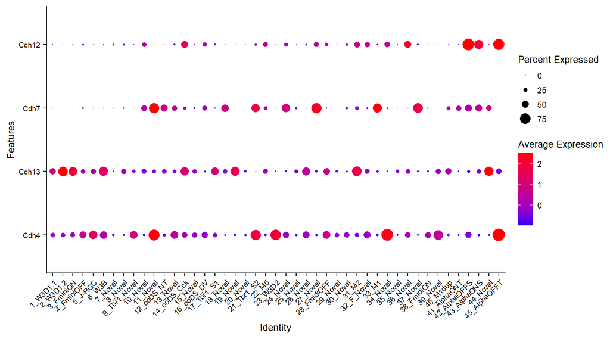

```r
DotPlot(object = TPM_Atlas, features = c("Cdh4", "Cdh13", "Cdh7", "Cdh12"),  cols = c("blue", "red")) + theme(text = element_text(size = 10), axis.text = element_text(size = 8) )  +  RotatedAxis() + coord_flip()
```

```r
markersF <- FindMarkers(object = TPM_Atlas, ident.1 = "3_FminiON", ident.2  = c("4_FminiOFF", "28_FmidiOFF","38_FmidiON"), logfc.threshold = 2 )
markersF
```

```
##        p_val avg_log2FC pct.1 pct.2 p_val_adj
## Rprm       0  -3.082423 0.156 0.928         0
## Tac1       0  -2.615951 0.081 0.777         0
## Foxp1      0  -2.098725 0.137 0.900         0
## Chrna6     0  -2.009660 0.141 0.910         0
```

Then we can take a look at the expression of these markers using dotplot, We only got 4:

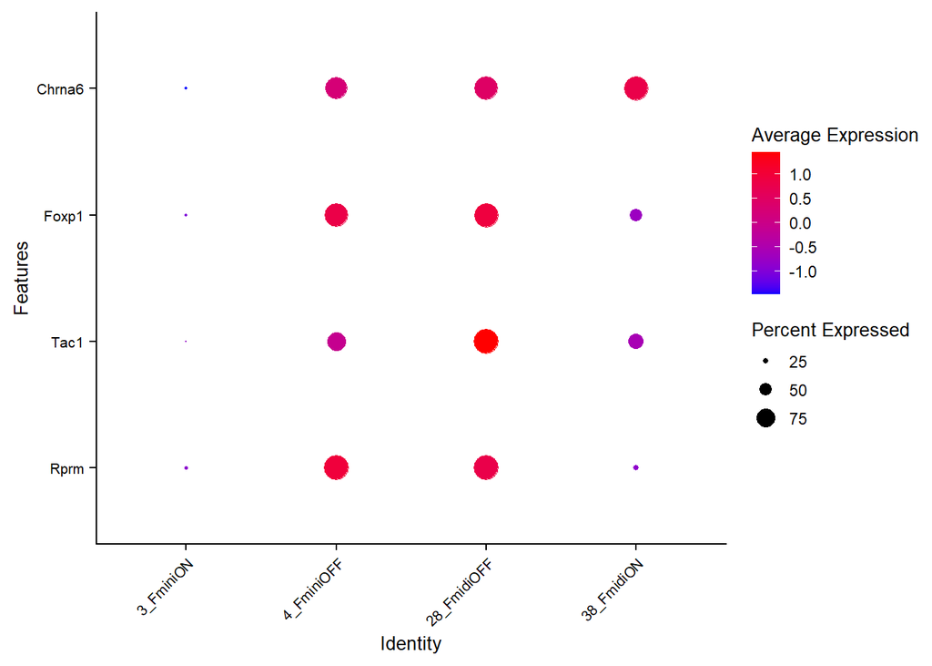

```r
DotPlot(object = TPM_Atlas, features = rownames(markersF),idents = c("3_FminiON",  "4_FminiOFF", "28_FmidiOFF","38_FmidiON")  , cols = c("blue", "red")) + theme(text = element_text(size = 10), axis.text = element_text(size = 8) )  +  RotatedAxis() + coord_flip()
```

Using this information you could find combination of markers that label specific cell types.